# Eksploracja_danych

##### Clerical

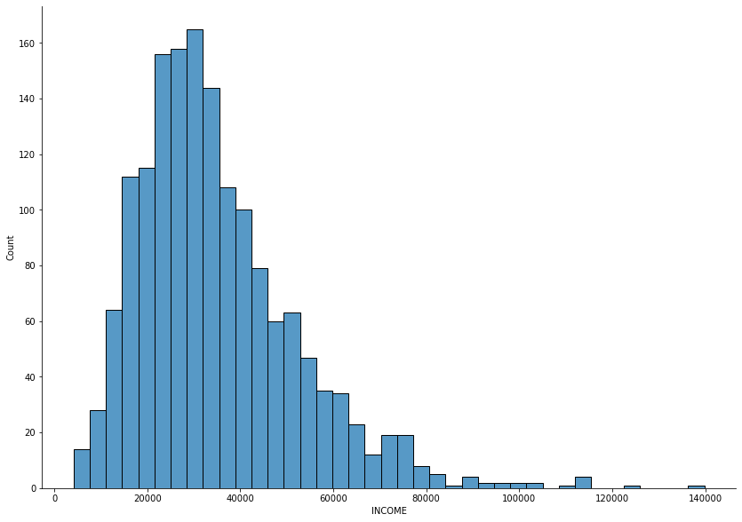

```python
sns.displot(clerical, x="INCOME", height=8.27, aspect=11.7/8.27)
```

##### Home Maker

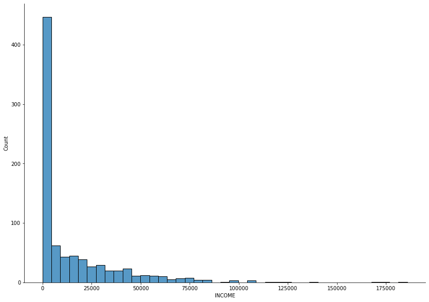

```python
sns.displot(home_maker, x="INCOME", height=8.27, aspect=11.7/8.27)
```

##### Student

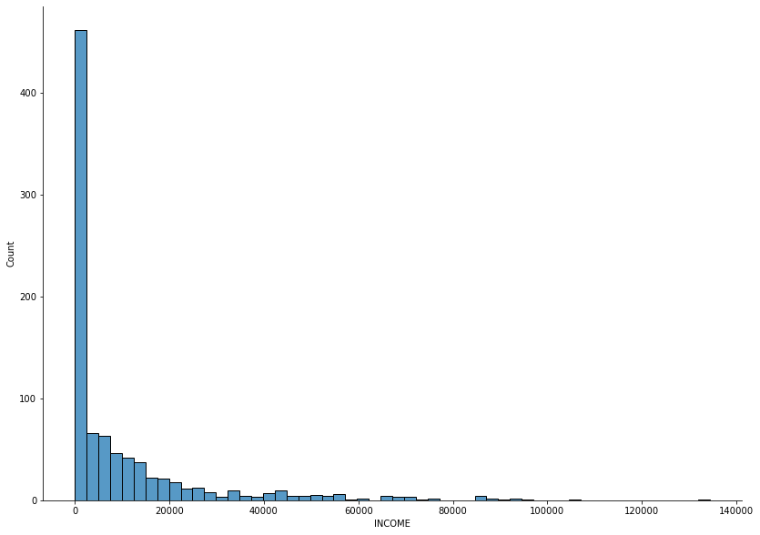

```python
sns.displot(student, x="INCOME", height=8.27, aspect=11.7/8.27)
```

Powyżej przedstawiono rozkłady dochodów dla poszczególnych zawodów. Charakteryzują się one asymetrią prawostronną, co z pewnością wpłynie na jakość imputacji, jednak imputację zawodu na podstawie dochodu uznano za najlepszy sposób dla posiadanych danych.

Dla każdego wiersza porównano zarobki ze średnimi zarobkami w danym zawodzie i znaleziono średnią dla takiego zawodu, której wartość zarobków w danym wierszu jest najbliższa.

```python
for i in range(0, nan.shape[0]):
    closest = closest_value(means, nan.iloc[i]["INCOME"])
    if closest == mean_professional:
        nan.iloc[i,11] = "Professional" #11, bo zmienna OCCUPATION jest w 11. kolumnie
    elif closest == mean_blue_collar:
        nan.iloc[i,11] = "Blue Collar"
    elif closest == mean_manager:
        nan.iloc[i,11] = "Manager"
    elif closest == mean_clerical:
        nan.iloc[i,11] = "Clerical"
    elif closest == mean_doctor:
        nan.iloc[i,11] = "Doctor"
    elif closest == mean_lawyer:
        nan.iloc[i,11] = "Lawyer"
    elif closest == mean_home_maker:
        nan.iloc[i,11] = "Home Maker"
    elif closest == mean_student:
        nan.iloc[i,11] = "Student"
```

Poniżej zamieniono kolumnę ze zmienną OCCUPATION w głównym zestawie danych na kolumnę, na której dokonano imputacji

```python
df.dropna(inplace=True)
df = df.append(nan)
df = df.sort_index()
```

### Analiza częstości szkód i średniej wartości szkody

Poniżej zaprezentowano serie wykresów ukazujących zależności pomiędzy częstością szkód oraz wartością szkody a poszczególnymi wariantami lub przedziałami wartości zmiennych, które mogą być potencjalnymi predyktorami prawdopodobieństwa i wartości szkód.

**Częstość szkód vs. zmienne ilościowe**

```
          CLAIM_FLAG  KIDSDRIV
KIDSDRIV
0           0.248539      9069
1           0.388060       804
2           0.396011       351
3           0.527027        74
4           0.500000         4
```

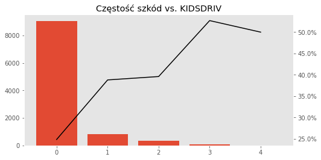

```
              CLAIM_FLAG   AGE
temp
(15.0, 22.0]    0.568627    51
(22.0, 29.0]    0.494220   346
(29.0, 36.0]    0.341929  1047
(36.0, 42.0]    0.298997  2592
(42.0, 48.0]    0.224032  2763
(48.0, 55.0]    0.189246  2399
(55.0, 62.0]    0.308422   843
(62.0, 68.0]    0.294372   231
(68.0, 74.0]    0.250000    20
(74.0, 81.0]    0.333333     3
```

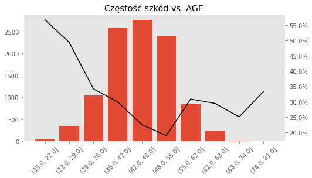

```
          CLAIM_FLAG  HOMEKIDS
HOMEKIDS
0           0.222587      6694
1           0.340868      1106
2           0.348984      1427
3           0.351636       856
4           0.358209       201
5           0.444444        18
```

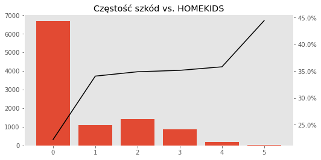

```
              CLAIM_FLAG   YOJ
temp
(-1.0, 2.0]     0.383234   835
(2.0, 5.0]      0.206897    87
(5.0, 7.0]      0.241983   343
(7.0, 9.0]      0.277449  1521
(9.0, 12.0]     0.261245  2201
(12.0, 14.0]    0.245481  2766
(14.0, 16.0]    0.245335  1822
(16.0, 18.0]    0.300000   160
(18.0, 21.0]    0.411765    17
(21.0, 23.0]    0.000000     2
```

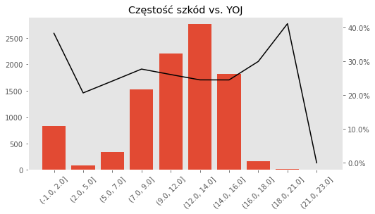

```
                      CLAIM_FLAG  INCOME
temp
(-368.0, 36703.0]       0.334548    3294
(36703.0, 73406.0]      0.287453    3204
(73406.0, 110109.0]     0.190375    1891
(110109.0, 146812.0]    0.172327     795
(146812.0, 183515.0]    0.163580     324
(183515.0, 220218.0]    0.152778     144
(220218.0, 256921.0]    0.105263      57
(256921.0, 293624.0]    0.235294      17
(293624.0, 330327.0]    0.250000       4
(330327.0, 367030.0]    0.000000       2
```

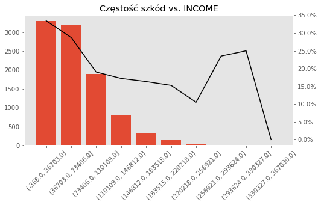

```
                      CLAIM_FLAG  HOME_VAL
temp
(-886.0, 88528.0]       0.369524      3196
(88528.0, 177056.0]     0.267484      2202
(177056.0, 265585.0]    0.228265      2519
(265585.0, 354113.0]    0.147107      1210
(354113.0, 442641.0]    0.117647       374
(442641.0, 531169.0]    0.128049       164
(531169.0, 619697.0]    0.120000        50
(619697.0, 708226.0]    0.333333         9
(708226.0, 796754.0]    0.500000         2
(796754.0, 885282.0]    0.000000         1
```

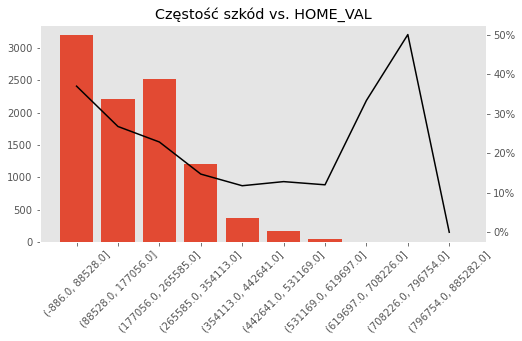

```
                CLAIM_FLAG  TRAVTIME
temp
(4.0, 19.0]       0.222885      1844
(19.0, 32.0]      0.252488      3216
(32.0, 46.0]      0.282195      3207
(46.0, 60.0]      0.313433      1474
(60.0, 74.0]      0.299550       444
(74.0, 87.0]      0.217391        92
(87.0, 101.0]     0.166667        18
(101.0, 115.0]    0.000000         4
(115.0, 128.0]    0.000000         1
(128.0, 142.0]    0.000000         2
```

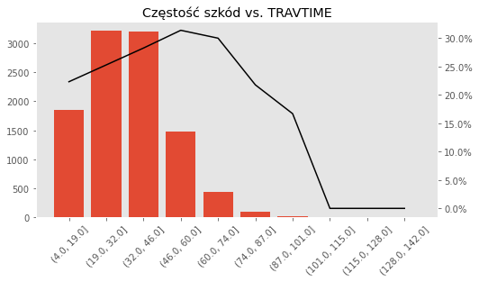

```
                    CLAIM_FLAG  BLUEBOOK
temp
(1431.0, 8324.0]      0.349091      2200
(8324.0, 15148.0]     0.268558      3314
(15148.0, 21972.0]    0.237927      2547
(21972.0, 28796.0]    0.234278      1447
(28796.0, 35620.0]    0.160410       586
(35620.0, 42444.0]    0.232704       159
(42444.0, 49268.0]    0.225000        40
(49268.0, 56092.0]    0.250000         4
(56092.0, 62916.0]    0.666667         3
(62916.0, 69740.0]    0.000000         2
```

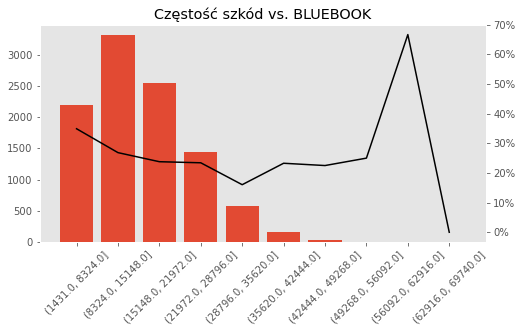

```
              CLAIM_FLAG   TIF
temp
(0.0, 3.0]      0.313562  3709
(3.0, 6.0]      0.263938  1686
(6.0, 8.0]      0.246986  2571
(8.0, 11.0]     0.212000  1250
(11.0, 13.0]    0.225352   710
(13.0, 15.0]    0.212121   132
(15.0, 18.0]    0.232955   176
(18.0, 20.0]    0.102041    49
(20.0, 23.0]    0.250000    16
(23.0, 25.0]    0.000000     3
```

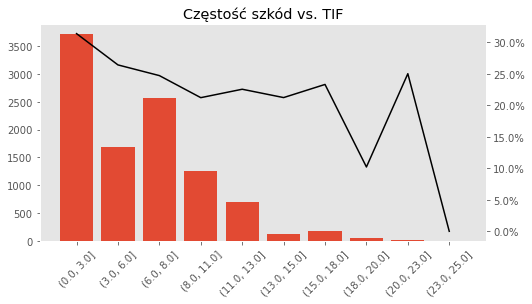

```
                    CLAIM_FLAG  OLDCLAIM
temp
(-58.0, 5704.0]       0.230449      8171
(5704.0, 11407.0]     0.408100      1284
(11407.0, 17111.0]    0.392157       102
(17111.0, 22815.0]    0.382114       123
(22815.0, 28518.0]    0.392638       163
(28518.0, 34222.0]    0.473373       169
(34222.0, 39926.0]    0.345324       139
(39926.0, 45630.0]    0.439560        91
(45630.0, 51333.0]    0.340426        47
(51333.0, 57037.0]    0.307692        13
```

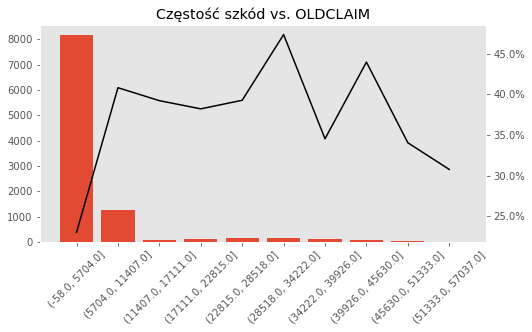

```
          CLAIM_FLAG  CLM_FREQ
CLM_FREQ
0           0.178481      6292
1           0.394058      1279
2           0.401475      1492
3           0.423387       992
4           0.413333       225
5           0.318182        22
```

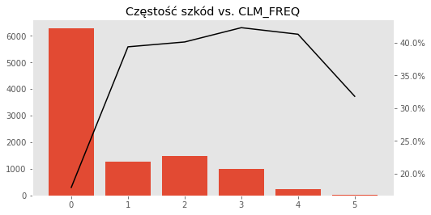

```
              CLAIM_FLAG  MVR_PTS
temp
(-1.0, 1.0]     0.203918     6125
(1.0, 3.0]      0.271893     1199
(3.0, 4.0]      0.325052      966
(4.0, 5.0]      0.368127     1255
(5.0, 6.0]      0.395894      341
(6.0, 8.0]      0.568075      213
(8.0, 9.0]      0.652695      167
(9.0, 10.0]     0.850000       20
(10.0, 12.0]    0.846154       13
(12.0, 13.0]    0.666667        3
```

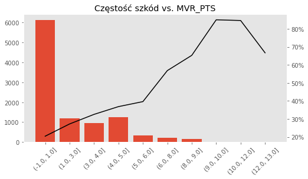

```
              CLAIM_FLAG  CAR_AGE
temp
(-1.0, 3.0]     0.330147     2511
(3.0, 6.0]      0.276667      600
(6.0, 8.0]      0.289543     1903
(8.0, 11.0]     0.249447     1808
(11.0, 14.0]    0.207159     1313
(14.0, 17.0]    0.195751      659
(17.0, 20.0]    0.207856      611
(20.0, 22.0]    0.190476      210
(22.0, 25.0]    0.139535       43
(25.0, 28.0]    0.000000        5
```

[1 more figures not shown]

```python
numeric_cols_predictors = []
for c in df.columns[1:]:
    if (str(df.loc[:, c].dtype) not in ['category', 'bool']) & (c != 'CLM_AMT'):
        numeric_cols_predictors.append(c)

for i in numeric_cols_predictors:
    fig, ax1 = plt.subplots(1, 1, figsize=(8, 4))
    ax2 = ax1.twinx()

    if len(df[i].unique()) > 10:
        df['temp'] = pd.cut(df[i], include_lowest=True, bins=10, precision=0)
        data_summary = df.groupby('temp').agg({'CLAIM_FLAG': 'mean', i: 'count'})
        ax1.bar(x=[str(item) for item in data_summary.index], height=data_summary[i])
        ax2.plot(data_summary['CLAIM_FLAG'], color='black')
        ax1.tick_params(axis='x', labelrotation = 45)
        del df['temp']
    else:
        data_summary = df.groupby(i).agg({'CLAIM_FLAG': 'mean', i: 'count'})
        ax1.bar(x=[str(item) for item in data_summary.index], height=data_summary[i])
        ax2.plot(data_summary['CLAIM_FLAG'], color='black')

    ax1.grid(False)
    ax2.grid(False)
    ax2.yaxis.set_major_formatter(PercentFormatter(1.0))
    plt.title(f'Częstość szkód vs. {i}')

    print(data_summary)
    plt.show()
```

Na podstawie powyższych wykresów można stwierdzić, że mogą istnieć istotne zależności pomiędzy potencjalnymi predyktorami a częstością występowania szkód. Częstość rośnie wraz ze wzrostem liczby dzieci, jako że rodzice niejednokrotnie umożliwiają dzieciom jazdę samochodami zarejestrowanymi na nich. Młodzi kierowcy natomiast częściej biorą udział w kolizcjach drogowych, co również potwierdza wizualizacja dotycząca wieku. Relacja pomiędzy częstością a wiekiem ma charakter nieliniowy również z ww. powodu - osoby powyżej 55 roku życia mają często dzieci, którym powierzają samochody. Częstość szkód znacząco rośnie w przypadku kierowców, którzy już w przeszłości brali udział w zdarzeniach drogowych i którzy są karani punktami karnymi. Również dłuższy czas dojazdu do pracy sprzyja częstszym zdarzeniom ubezpieczeniowym. Niższe częstości można zaobserwować w przypadku osób o wyższych dochodach i droższych domach oraz tych którzy pozostają klientami przez dłuższy czas. Częstość szkód maleje również wraz z wiekiem pojazdu.

**Częstość szkód vs. zmienne jakościowe**

```
         CLAIM_FLAG  PARENT1
PARENT1
False      0.239424     8959
True       0.447506     1343
```

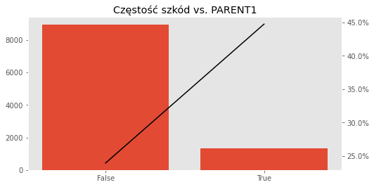

```
         CLAIM_FLAG  MSTATUS
MSTATUS
False      0.336898     4114
True       0.219780     6188
```

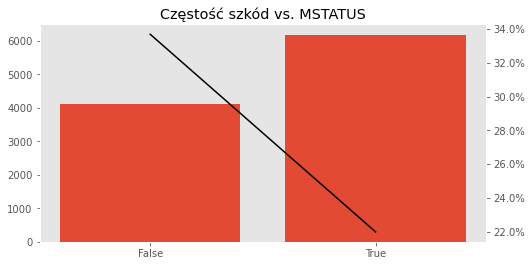

```
        CLAIM_FLAG  GENDER
GENDER
F         0.275564    5545
M         0.256044    4757
```

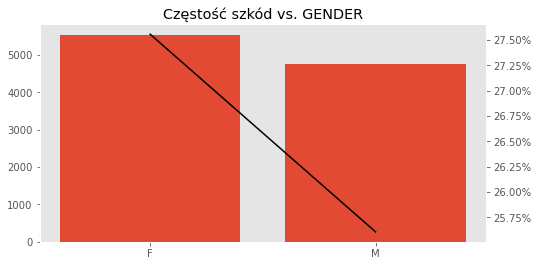

```
              CLAIM_FLAG  EDUCATION
EDUCATION
<High School    0.324752       1515
High School     0.346545       2952
Bachelors       0.238399       2823
Masters         0.194418       2078
PhD             0.164882        934
```

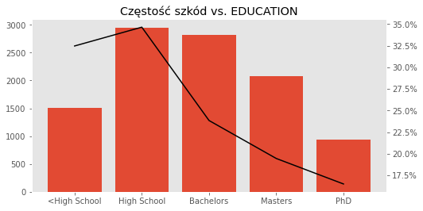

```
              CLAIM_FLAG  OCCUPATION
OCCUPATION
Blue Collar     0.350962        2288
Clerical        0.302516        1590
Doctor          0.115265         321
Home Maker      0.271649         843
Lawyer          0.180407        1031
Manager         0.135243        1257
Professional    0.230824        1408
Student         0.379310         899
```

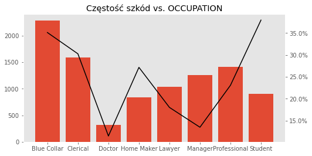

```
            CLAIM_FLAG  CAR_USE
CAR_USE
Commercial    0.345738     3789
Private       0.220482     6513
```

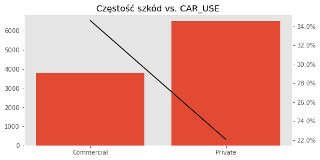

```
             CLAIM_FLAG  CAR_TYPE
CAR_TYPE
Minivan        0.172606      2694
Panel Truck    0.263775       853
Pickup         0.313205      1772
SUV            0.291710      2883
Sports Car     0.346056      1179
Van            0.273616       921
```

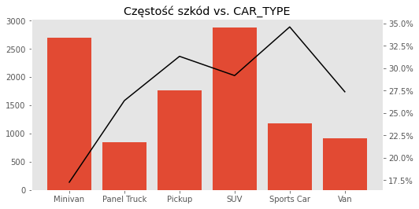

```
         CLAIM_FLAG  RED_CAR
RED_CAR
False      0.268632     7326
True       0.261425     2976
```

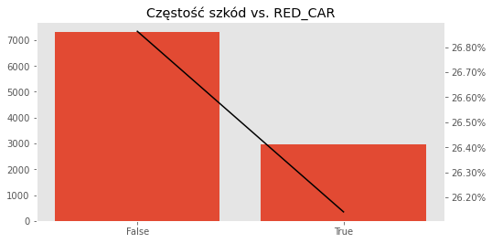

```
         CLAIM_FLAG  REVOKED
REVOKED
False      0.240792     9041
True       0.451229     1261
```

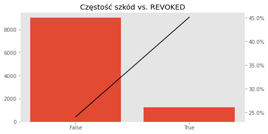

```
                     CLAIM_FLAG  URBANICITY
URBANICITY
Highly Rural/ Rural    0.064672        2072
Highly Urban/ Urban    0.317375        8230
```

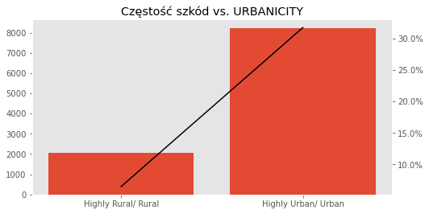

```python
categorical_cols_predictors = []
for c in df.columns[1:]:
    if (str(df.loc[:, c].dtype) in ['category', 'bool']) & (c != 'CLAIM_FLAG'):
        categorical_cols_predictors.append(c)

for i in categorical_cols_predictors:
    fig, ax1 = plt.subplots(1, 1, figsize=(8, 4))
    ax2 = ax1.twinx()

    data_summary = df.groupby(i).agg({'CLAIM_FLAG': 'mean', i: 'count'})
    if i == 'EDUCATION':
        data_summary = data_summary.reindex(['<High School', 'High School', 'Bachelors', 'Masters', 'PhD'])

    ax1.bar(x=[str(item) for item in data_summary.index], height=data_summary[i])
    ax2.plot(data_summary['CLAIM_FLAG'], color='black')
    ax1.grid(False)
    ax2.grid(False)
    ax2.yaxis.set_major_formatter(PercentFormatter(1.0))
    plt.title(f'Częstość szkód vs. {i}')

    print(data_summary)
    plt.show()
```

Wyraźne zależności widoczne są również na wykresach prezentujących zmienne jakościowe. Częstość szkód rośnie w przypadku samotnych rodziców, a maleje w przypadku osób posiadjących partnera. Wraz ze wzrostem wykształcenia ubezpieczeni rzadziej biorą udział w kolizjach. Wykorzystanie pojazdu w celach komercyjnych koreluje z częstszymi kolizjami. Posiadacze pojazdów sportowych powodują szkody częściej niż właściciele innych pojazdów. Osoby, którym odebrano w przeszłości prawo jazdy, kiedy prowadzą pojazdy nadal stwarzają większe zagrożenie niż pozostali. Wyższe częstości można zaobserwować również w rejonach wysoko zurbanizowanych.

**Średnia szkoda vs. zmienne ilościowe**

```
          KIDSDRIV      CLM_AMT
KIDSDRIV
0             2254  5587.189453
1              312  5920.679688
2              139  6626.668945
3               39  5104.487305
4                2  4054.000000
```

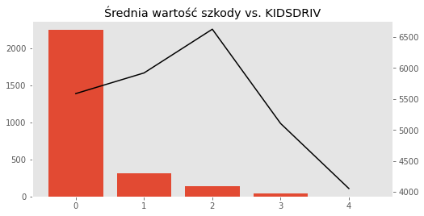

```
              AGE      CLM_AMT
temp
(15.0, 22.0]   29  6947.482910
(22.0, 28.0]  145  5333.048340
(28.0, 34.0]  299  5172.986816
(34.0, 40.0]  631  5809.427734
(40.0, 46.0]  653  5625.661621
(46.0, 52.0]  475  5647.425293
(52.0, 58.0]  335  5909.077637
(58.0, 64.0]  149  6010.073730
(64.0, 70.0]   19  5631.000000
(70.0, 76.0]    5  3610.800049
```

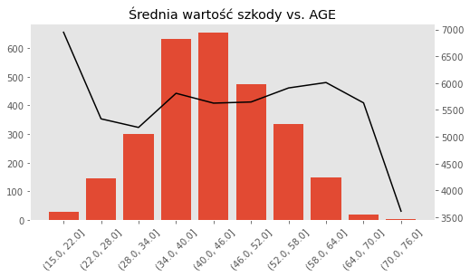

```
          HOMEKIDS      CLM_AMT
HOMEKIDS
0             1490  5640.871582
1              377  5331.228027
2              498  6032.614258
3              301  5674.269043
4               72  5639.944336
5                8  4502.750000
```

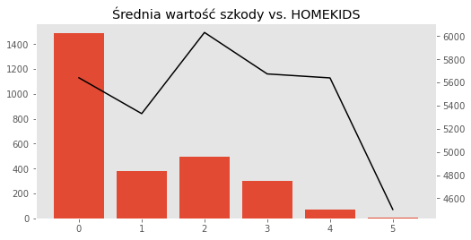

```
              YOJ      CLM_AMT
temp
(-1.0, 2.0]   316  5036.579102
(2.0, 4.0]     12  4495.666504
(4.0, 6.0]     35  4019.628662
(6.0, 8.0]    141  6886.851074
(8.0, 10.0]   339  5702.495605
(10.0, 11.0]  575  5834.342773
(11.0, 13.0]  679  5574.896973
(13.0, 15.0]  381  5608.314941
(15.0, 17.0]  107  5899.532715
(17.0, 19.0]   14  4128.714355
```

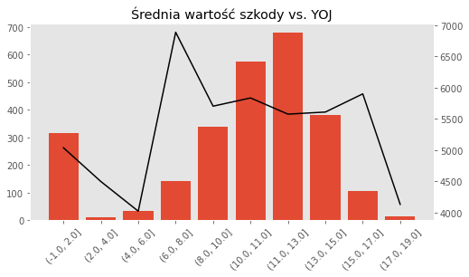

```
                      INCOME      CLM_AMT
temp
(-321.0, 32013.0]        961  5084.868652
(32013.0, 64025.0]       862  5859.508301
(64025.0, 96038.0]       457  6200.028320
(96038.0, 128051.0]      193  6357.569824
(128051.0, 160064.0]      74  6521.824219
(160064.0, 192076.0]      29  5203.827637
(192076.0, 224089.0]      19  5089.947266
(224089.0, 256102.0]       6  7034.000000
(256102.0, 288114.0]       3  3163.666748
(288114.0, 320127.0]       2  3069.500000
```

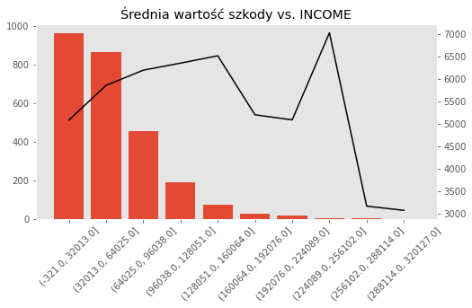

```
                      HOME_VAL      CLM_AMT
temp
(-751.0, 75046.0]         1138  5544.664551
(75046.0, 150091.0]        412  4923.434570
(150091.0, 225136.0]       602  5846.559570
(225136.0, 300182.0]       288  5743.506836
(300182.0, 375228.0]        98  7264.785645
(375228.0, 450273.0]        31  5983.290527
(450273.0, 525318.0]        18  4393.555664
(525318.0, 600364.0]         6  5336.333496
(600364.0, 675410.0]         3  4224.000000
(675410.0, 750455.0]         2  3069.500000
```

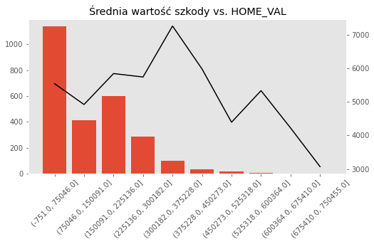

```
              TRAVTIME      CLM_AMT
temp
(4.0, 14.0]        273  5243.003906
(14.0, 23.0]       362  5880.994629
(23.0, 33.0]       588  5847.229492
(33.0, 42.0]       624  5450.684082
(42.0, 51.0]       524  5741.333984
(51.0, 60.0]       240  5544.608398
(60.0, 69.0]        96  6251.677246
(69.0, 79.0]        28  6430.643066
(79.0, 88.0]         8  3403.250000
(88.0, 97.0]         3  7599.666504
```

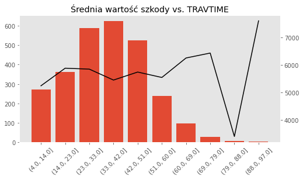

```
                    BLUEBOOK       CLM_AMT
temp
(1438.0, 7574.0]         670   4233.809082
(7574.0, 13648.0]        811   5679.537598
(13648.0, 19722.0]       615   5858.104004
(19722.0, 25796.0]       401   6779.638184
(25796.0, 31870.0]       160   6700.531250
(31870.0, 37944.0]        60   8644.683594
(37944.0, 44018.0]        20   8359.099609
(44018.0, 50092.0]         6   3595.666748
(50092.0, 56166.0]         1  18084.000000
(56166.0, 62240.0]         2   3667.500000
```

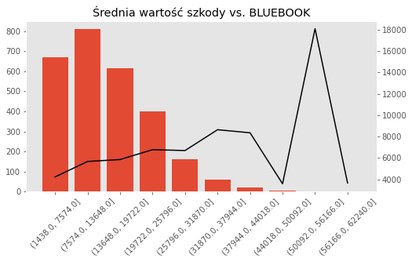

```
               TIF      CLM_AMT
temp
(0.0, 3.0]    1163  5820.865234
(3.0, 5.0]     445  5223.231445
(5.0, 7.0]     608  5876.082031
(7.0, 9.0]      93  4457.871094
(9.0, 11.0]    267  5886.266113
(11.0, 13.0]    92  5781.217285
(13.0, 15.0]    28  4867.643066
(15.0, 17.0]    41  4971.438965
(17.0, 19.0]     5  4926.799805
(19.0, 21.0]     4  4890.250000
```

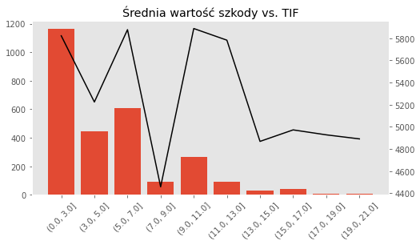

```
                    OLDCLAIM      CLM_AMT
temp
(-58.0, 5704.0]         1883  5639.087402
(5704.0, 11407.0]        524  5846.431152
(11407.0, 17111.0]        40  4860.475098
(17111.0, 22815.0]        47  4685.127441
(22815.0, 28518.0]        64  5277.500000
(28518.0, 34222.0]        80  6220.912598
(34222.0, 39926.0]        48  6166.500000
(39926.0, 45630.0]        40  5982.725098
(45630.0, 51333.0]        16  5379.625000
(51333.0, 57037.0]         4  3926.750000
```

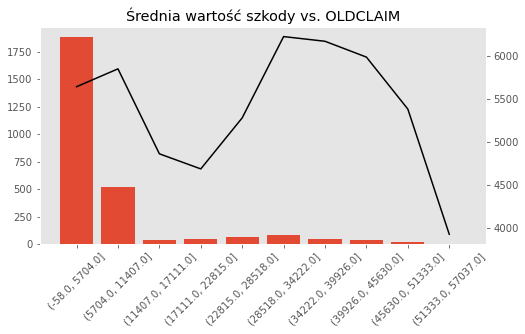

```
          CLM_FREQ      CLM_AMT
CLM_FREQ
0             1123  5602.553223
1              504  5829.678711
2              599  5354.876465
3              420  6139.361816
4               93  5628.042969
5                7  4247.285645
```

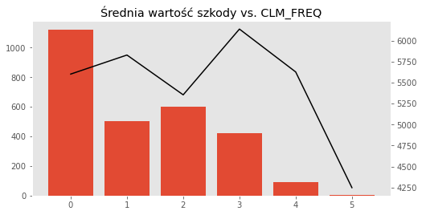

```
              MVR_PTS      CLM_AMT
temp
(-1.0, 1.0]      1249  5427.648438
(1.0, 3.0]        326  6061.052246
(3.0, 4.0]        314  5260.165527
(4.0, 5.0]        462  5796.149414
(5.0, 6.0]        135  6809.170410
(6.0, 8.0]        121  5736.851074
(8.0, 9.0]        109  6376.119141
(9.0, 10.0]        17  7196.353027
(10.0, 12.0]       11  4201.181641
(12.0, 13.0]        2  3786.500000
```

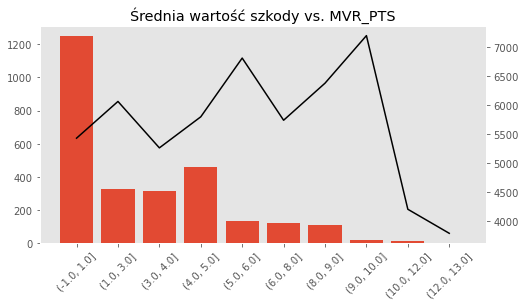

```
              CAR_AGE      CLM_AMT
temp
(-1.0, 2.0]       829  5800.449707
(2.0, 5.0]        166  5946.343262
(5.0, 8.0]        343  5911.801758
(8.0, 10.0]       543  5399.580078
(10.0, 12.0]      224  6181.518066
(12.0, 15.0]      235  5216.783203
(15.0, 18.0]      110  5052.672852
(18.0, 20.0]      102  5960.882324
(20.0, 22.0]       13  4540.077148
(22.0, 25.0]        6  4046.833252
```

[1 more figures not shown]

```python
df_non_zero_claims = df[df['CLM_AMT'] > 0]
for i in numeric_cols_predictors:
    fig, ax1 = plt.subplots(1, 1, figsize=(8, 4))
    ax2 = ax1.twinx()

    if len(df_non_zero_claims[i].unique()) > 10:
        df_non_zero_claims['temp'] = pd.cut(df_non_zero_claims[i], include_lowest=True, bins=10, precision=0)
        data_summary = df_non_zero_claims.groupby('temp').agg({i: 'count', 'CLM_AMT': 'mean'})
        ax1.bar(x=[str(item) for item in data_summary.index], height=data_summary[i])
        ax2.plot(data_summary['CLM_AMT'], color='black')
        ax1.tick_params(axis='x', labelrotation = 45)
        del df_non_zero_claims['temp']
    else:
        data_summary = df_non_zero_claims.groupby(i).agg({i: 'count', 'CLM_AMT': 'mean'})
        ax1.bar(x=[str(item) for item in data_summary.index], height=data_summary[i])
        ax2.plot(data_summary['CLM_AMT'], color='black')

    ax1.grid(False)
    ax2.grid(False)
    plt.title(f'Średnia wartość szkody vs. {i}')

    print(data_summary)
    plt.show()
```

W przypadku średniej szkody zależności nie są już tak wyraźne. Na podstawie powyższych wykresów można stweirdzić przede wszystkim zależność pomiędzy zmiennymi takimi jak wartość pojazdu, dochód i wartość domu a wartością szkody. Prawdopodobnie głównym czynnikiem jest tu wartość pojazdu, która im wyższa, tym wyższego wymaga odszkodowania w wyniku kolizji.

**Średnia szkoda vs. zmienne jakościowe**

```
             CLM_AMT  PARENT1      BLUEBOOK      coef
PARENT1
False    5576.806641     2145  14377.151367  0.387894
True     6001.359375      601  13640.250000  0.439974
```

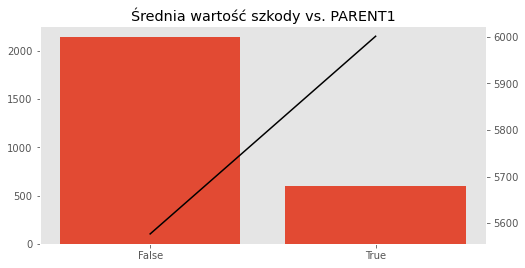

```
             CLM_AMT  MSTATUS      BLUEBOOK      coef
MSTATUS
False    5928.080078     1386  14449.083984  0.410274
True     5406.432129     1360  13978.198242  0.386776
```

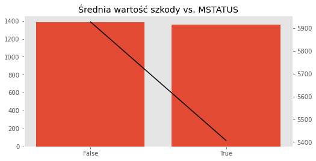

```
            CLM_AMT  GENDER      BLUEBOOK      coef
GENDER
F       5430.478516    1528  13573.795898  0.400071
M       5969.865234    1218  15021.363281  0.397425
```

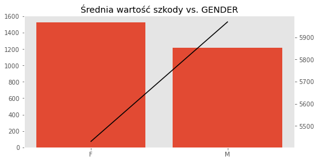

```
                  CLM_AMT  EDUCATION      BLUEBOOK      coef
EDUCATION
<High School  5712.190918        492  11780.507812  0.484885
High School   5315.484863       1023  12725.415039  0.417706
Bachelors     5965.903320        673  15098.410156  0.395135
Masters       5738.131348        404  17388.687500  0.329992
PhD           6413.441406        154  19716.947266  0.325276
```

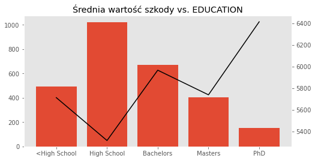

```
                  CLM_AMT  OCCUPATION      BLUEBOOK      coef
OCCUPATION
Blue Collar   5918.647461         803  14229.651367  0.415938
Clerical      5345.862793         481  12084.594727  0.442370
Doctor        4985.486328          37  16873.244141  0.295467
Home Maker    4996.689941         229  11137.161133  0.448650
Lawyer        5681.435547         186  15451.666992  0.367691
Manager       5011.876465         170  16347.293945  0.306588
Professional  6471.055176         325  17014.646484  0.380323
Student       5181.624512         341  10339.413086  0.501153
```

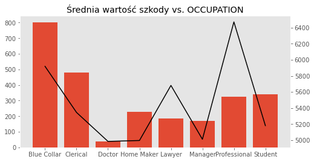

```
                CLM_AMT  CAR_USE      BLUEBOOK      coef
CAR_USE
Commercial  6085.095215     1310  16392.732422  0.371207
Private     5290.802246     1436  12230.013672  0.432608
```

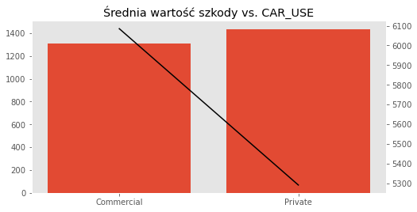

```
                 CLM_AMT  CAR_TYPE      BLUEBOOK      coef
CAR_TYPE
Minivan      5434.137695       465  14040.300781  0.387039
Panel Truck  7243.502441       225  28924.888672  0.250425
Pickup       5588.524414       555  11803.874023  0.473448
SUV          5396.087891       841  11561.676758  0.466722
Sports Car   5172.963379       408  11184.607422  0.462507
Van          6595.615234       252  20484.523438  0.321980
```

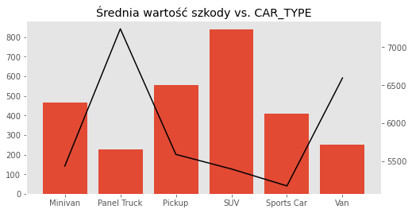

```
             CLM_AMT  RED_CAR      BLUEBOOK      coef
RED_CAR
False    5580.671387     1968  13890.955078  0.401749
True     5894.994629      778  15037.763672  0.392013
```

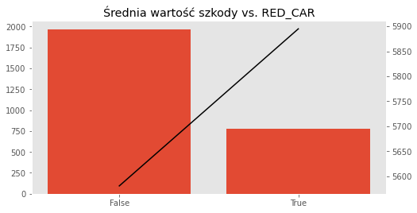

```
             CLM_AMT  REVOKED      BLUEBOOK      coef
REVOKED
False    5745.056152     2177  14274.023438  0.402483
True     5381.511230      569  13993.374023  0.384576
```

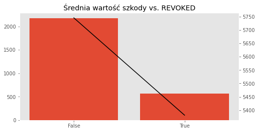

```
                         CLM_AMT  URBANICITY      BLUEBOOK      coef
URBANICITY
Highly Rural/ Rural  5671.955078         134  12092.537109  0.469046
Highly Urban/ Urban  5669.611328        2612  14324.800781  0.395790
```

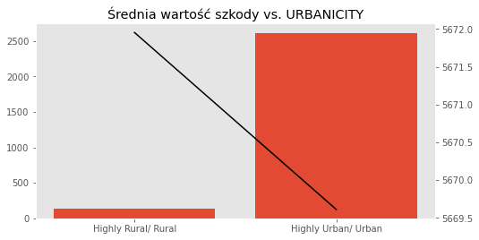

```python
df_non_zero_claims = df[df['CLM_AMT'] > 0]

for i in categorical_cols_predictors:
    fig, ax1 = plt.subplots(1, 1, figsize=(8, 4))
    ax2 = ax1.twinx()

    data_summary = df_non_zero_claims.groupby(i).agg({'CLM_AMT': 'mean', i: 'count', 'BLUEBOOK': 'mean'})
    if i == 'EDUCATION':
        data_summary = data_summary.reindex(['<High School', 'High School', 'Bachelors', 'Masters', 'PhD'])

    ax1.bar(x=[str(item) for item in data_summary.index], height=data_summary[i])
    ax2.plot(data_summary['CLM_AMT'], color='black')
    ax1.grid(False)
    ax2.grid(False)
    plt.title(f'Średnia wartość szkody vs. {i}')

    data_summary['coef'] = data_summary['CLM_AMT'] / data_summary['BLUEBOOK']
    print(data_summary)
    plt.show()
```

Osoby samotnie wychowujące dzieci lub po prostu nie posiadające partnera charkateryzują się wyższymi szkodami. Wartość szkód jest również wyższa dla mężczyzn oraz osób wykształconych, co można powiązać z większą zamożnością i, ponownie, z wyższą wartością pojazdów. Wyższe odszkodowania są wypłacane również w przypadku pojazdów służących do przewozu towarów, takich jak furgonetki i samochody typu van.